# Introduction to fitting statistical models to collections of enhancers

Noah Dukler

2018-04-02

## Statistical models for super-enhancers

Activity model is $A({\boldsymbol{\mathbf{x}}}) = \beta_0 + \beta_1 x_1 + \beta_2 x_2 + \cdots + \beta_n x_n$.

Exponential model is $R({\boldsymbol{\mathbf{x}}}) = e^{A({\boldsymbol{\mathbf{x}}})} + \epsilon$.

Logistic model is $R({\boldsymbol{\mathbf{x}}})=1/\left(1+e^{-A({\boldsymbol{\mathbf{x}}})}\right)+\epsilon$.

## Fitting your first model

To start fitting statistical models to your enhancer data you need to format your data in a particular way. First you need to place information about which enhancers are present in each experiment in a data.frame where each row is an experiment and each column is an enhancer element. Here’s a simple example using the data from Shin et al. (2015):

```r
library(superEnhancerModelR)
data("wap")
design = wap[,c(3:5)]
head(design)
```

```
##   E1 E2 E3
## 1  1  1  1
## 2  1  1  1
## 3  1  1  1
## 4  1  1  1
## 5  1  1  1
## 6  1  1  1
```

Then we need a vector of normalized expression values, with each element of the vector corresponding to one row of the previous data frame.

```r
## Create "expression data""
expression = wap[,2]
print(head(expression))
```

```
## [1] 141.60 110.68  47.72 114.84 130.00  62.14
```

Once we have both expression values and a design matrix, we can construct an enhancerDataObject. This object holds the raw data, the design of each experiment, and detail of the statistical model that you want to fit. You can specify the link function: additive, exponential, or logistic (from Dukler et al., 2017). You can also specify an error model: Gaussian, or log-normal. Upper and lower bounds for all parameters can also be specified although we will leave them at the defaults for now. We specify a model with a logistic link function, log-normal error, and non-interacting enhancer loci as follows:

```r
## Create activity function
actFun = formula(~E1+E2+E3)
independent.loci = enhancerDataObject(expression,design,actFun,errorModel="lognormal",linkFunction="logistic")
```

This model can then be fit using a differential evolutionary algorithm and refined with gradient descent (note that this step could be run with more iterations.):

```r
independent.loci=optimDE(independent.loci,maxit=600,refine=TRUE)
```

```
## Iteration: 100 bestvalit: 181.042039 bestmemit:   -5.593853  404.683996  490.979213  215.006205   29.624805    1.095904
## Iteration: 200 bestvalit: 169.444629 bestmemit:   -5.641673    4.483550    0.712109  584.769901   32.930709    0.941444
## Iteration: 300 bestvalit: 162.840383 bestmemit:   -6.326603    4.263354    0.712109    6.638298   40.445787    0.759417
## Iteration: 400 bestvalit: 157.722512 bestmemit:   -6.095044    3.427299    0.845448    5.280577   55.262841    0.651973
## Iteration: 500 bestvalit: 156.524036 bestmemit:   -6.224139    3.008940    1.210645    4.540680   73.875316    0.619457
## Iteration: 600 bestvalit: 156.514270 bestmemit:   -6.240133    2.999193    1.209066    4.560465   74.327728    0.621024
```

Once you have a fitted model you can plot the data and the predicted model

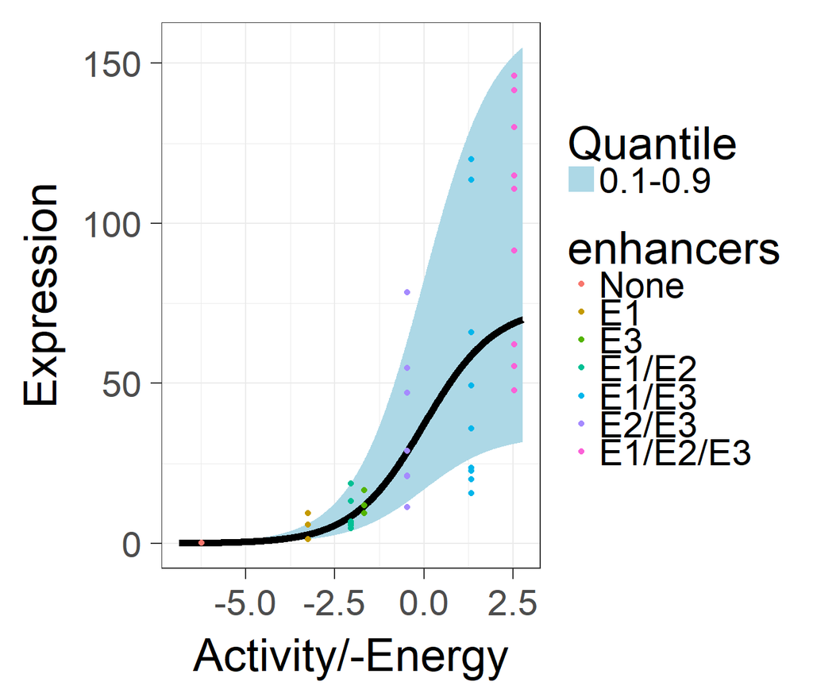

```r
plotModel(independent.loci)
```

You can also view the model residuals

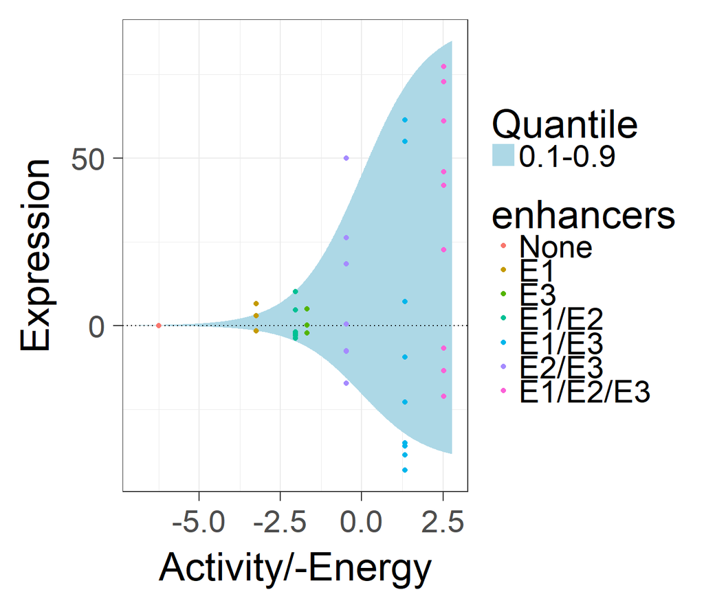

```r
plotResiduals(independent.loci)
```

```r
actFun2 = formula(~E1+E2+E1*E2)
dependent.loci = enhancerDataObject(expression,design,actFun2,errorModel="lognormal",linkFunction="logistic")
dependent.loci=optimDE(dependent.loci,maxit=600,refine=TRUE)
```

```
## Iteration: 100 bestvalit: 193.367025 bestmemit:   -2.396220  456.779276  681.166259  747.159723   17.817501    1.789534
## Iteration: 200 bestvalit: 190.237447 bestmemit:   -3.086789  851.563791  344.702928  971.105489   28.077678    1.411484
## Iteration: 300 bestvalit: 190.031846 bestmemit:   -3.157835    4.115244  940.149383 -538.881034   31.138244    1.405792
## Iteration: 400 bestvalit: 190.029065 bestmemit:   -3.206192    4.165657    8.974935   -0.388937   31.358577    1.405746
## Iteration: 500 bestvalit: 190.029061 bestmemit:   -3.206910    4.163128    8.670896  485.233914   31.387658    1.405744
## Iteration: 600 bestvalit: 190.029061 bestmemit:   -3.206913    4.163120    8.655204  258.404048   31.386786    1.405740
```

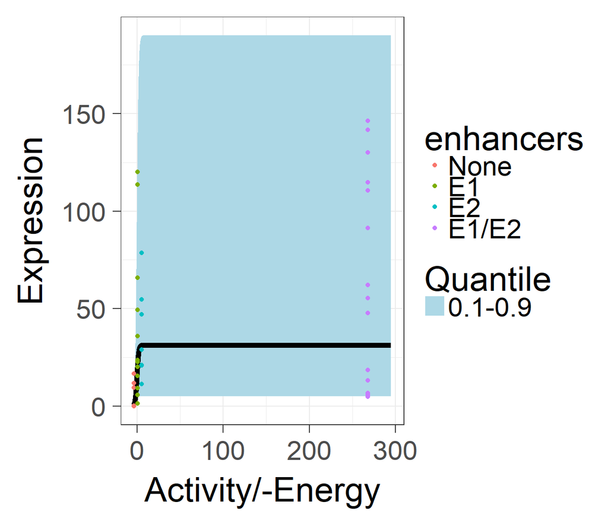

```r
plotModel(dependent.loci)
```

Then we can compare their respective Bayesian information criterion (BIC). Lower BIC indicates a better model.

```r
paste("The BIC for the interacting loci model is:",bic(dependent.loci))
```

```
## [1] "The BIC for the interacting loci model is: 402.339554976584"
```

```r
paste("The BIC for the independent loci model is:",bic(independent.loci))
```

```
## [1] "The BIC for the independent loci model is: 335.308811632036"
```

The significance of a difference in Bayes factor can be interpreted using this table.

| $\Delta BIC$ | Evidence against higher BIC |
| --- | --- |
| 0 to 2 | Not worth more than a bare mention |
| 2 to 6 | Positive |
| 6 to 10 | Strong |
| >10 | Very Strong |

If you want p-values for individual coefficients, run the function computeParamPvals and it will calculate the significance of the each parameter via the likelihood-ratio test.

```r
param.stats=computeParamPvals(independent.loci,maxit=600)
```

```
## Fitting reduced model without term (Intercept)
## Iteration: 100 bestvalit: 195.407625 bestmemit:   -1.433418  714.335827  755.379884 -560.958026   21.155617    1.606272
## Iteration: 200 bestvalit: 193.714505 bestmemit:   -1.697644    0.869634  271.654331 -377.522908   26.350451    1.576753
## Iteration: 300 bestvalit: 193.686871 bestmemit:   -1.689851    0.822005  562.697846 -139.459191   26.313028    1.536870
## Iteration: 400 bestvalit: 193.686871 bestmemit:   -1.689336    0.821463  993.701877  241.204207   26.314024    1.536917
## Iteration: 500 bestvalit: 193.686871 bestmemit:   -1.689337    0.821463  875.164283  355.273678   26.314028    1.536917
## Iteration: 600 bestvalit: 193.686871 bestmemit:   -1.689337    0.821463  656.691970  925.536277   26.314028    1.536917
## Fitting reduced model without term E1
## Iteration: 100 bestvalit: 183.842775 bestmemit:   -3.930251   23.909813  772.981460 -560.117709   28.907212    1.281538
## Iteration: 200 bestvalit: 179.576340 bestmemit:   -3.772157    2.220455  330.323225 -152.578935   45.482383    1.336116
## Iteration: 300 bestvalit: 176.015605 bestmemit:   -4.200932    2.340683    5.319468 -471.460437   48.056430    1.021729
## Iteration: 400 bestvalit: 175.276469 bestmemit:   -4.458646    2.540721    4.404705 -209.610695   61.753045    0.987589
## Iteration: 500 bestvalit: 175.272224 bestmemit:   -4.479001    2.524867    4.381270 -403.842807   62.772552    0.980770
## Iteration: 600 bestvalit: 175.272217 bestmemit:   -4.479018    2.523697    4.382160  648.045083   62.760890    0.980838
## Fitting reduced model without term E2
## Iteration: 100 bestvalit: 180.827787 bestmemit:   -5.410394  974.653525  891.185904   61.725177   27.338407    1.149372
## Iteration: 200 bestvalit: 168.652655 bestmemit:   -6.093571    4.558600   64.151977 -326.718151   36.311260    1.005480
## Iteration: 300 bestvalit: 160.180948 bestmemit:   -6.195178    3.974161    5.676069 -543.470650   63.805270    0.680326
## Iteration: 400 bestvalit: 160.151423 bestmemit:   -6.248080    4.078413    5.747050  430.878727   62.667463    0.678365
## Iteration: 500 bestvalit: 160.151400 bestmemit:   -6.250176    4.079023    5.748129  683.728319   62.722135    0.678300
## Iteration: 600 bestvalit: 160.151400 bestmemit:   -6.250167    4.079037    5.748123   -5.783787   62.721589    0.678304
## Fitting reduced model without term E3
## Iteration: 100 bestvalit: 191.697659 bestmemit:   -1.978612  219.317532   71.404952 -138.390640   21.329847    1.447681
## Iteration: 200 bestvalit: 190.062274 bestmemit:   -3.046474    3.984721  457.090430  272.563320   30.419376    1.399159
## Iteration: 300 bestvalit: 190.029085 bestmemit:   -3.205015    4.167818  472.414804 -253.147132   31.343544    1.405868
## Iteration: 400 bestvalit: 190.029062 bestmemit:   -3.206990    4.164039    8.685672  460.162061   31.382643    1.405735
## Iteration: 500 bestvalit: 190.029061 bestmemit:   -3.206983    4.162942    8.639778  -80.672432   31.388866    1.405740
## Iteration: 600 bestvalit: 190.029061 bestmemit:   -3.206983    4.162946    8.639642  335.441415   31.388910    1.405740
```

```r
param.stats$pVals
```

```
##     parameter        ll         D        p.val
## 1 (Intercept) -193.6869 74.346363 3.320265e-18
## 2          E1 -175.2722 37.517056 4.645908e-10
## 3          E2 -160.1514  7.275422 3.891735e-03
## 4          E3 -190.0291 67.030743 1.355914e-16
```